'Sample 2 - Plot error bars and functions.ipynb' 8/27/19 D. Candela

# Sample notebook 2: Plotting error bars and plotting functions

### Plotting error bars

This builds on **Sample notebook 1: Plotting manually entered data.**

To plot points with error bars, `plt.errorbar` is used in place of `plt.plot`. This function requires three lists or arrays of values: The $x$-values, the $y$-values, and the $y$ error bars (measured from the symbol to one end of the error bar).

Here is an example:

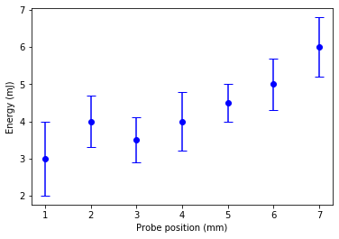

```python
import matplotlib.pyplot as plt
%matplotlib inline

# Enter  x, y, and y-error values
xs = [1,2,3,4,5,6,7]
ys = [3,4,3.5,4,4.5,5,6]
yerrs = [1,.7,.6,.8,.5,.7,.8]

# Make the error bar plot
plt.errorbar(xs,ys,yerrs,fmt='bo',capsize=5)

# Add labels and show
plt.xlabel('Probe position (mm)')
plt.ylabel('Energy (mJ)')
plt.show()
```

Notes:

- For `plt.errorbar`, the format specifier (`'bo'` = blue dots, no line) must be entered as shown above using `fmt=..`.
- If you like caps on the ends of your error bars you must supply `capsize=..` as shown.
- You can addtionally or alternatively plot horizontal ($x$) error bars by supplying `xerr=..`.

### Using `numpy`

For the remaining topics in these notebooks (plotting functions, reading data from a file, fitting data to models) we need to use the `numpy` package in addition to the `pyplot` package used to make plots.

`numpy` includes most common scientific functions like square root, trig and exponential functions (list is is [here](https://docs.scipy.org/doc/numpy-1.13.0/reference/routines.math.html); more esoteric functions can be found [here](https://docs.scipy.org/doc/scipy/reference/special.html)). Once we import numpy we could use these functions as `np.sqrt`, etc., but it is handier to import needed scientific functions explicitly so the `np.--` is not required. Therefore, **import statements like the following should be executed near the beginning of most Python notebooks that do scientific calculations:**

```python
import matplotlib.pyplot as plt
%matplotlib inline

import numpy as np
# Following statement should include scientific functions
# to be used, including square root and the constant pi
from numpy import sqrt,pi,sin,cos

# Example of use:
print(f'Square root of cosine of pi/3 = {sqrt(cos(pi/3))}')
```

```
Square root of cosine of pi/3 = 0.7071067811865476
```

### Plotting functions

Say you want to plot the function $$ f(x) = A\cos(\pi x^2) $$ over the range $x_1 \leq x \leq x_2$. In Python as in other computer languages we do this by plotting lines connecting a few hundred $(x,f(x))$ points to give the appeance of a smooth curve, as follows:

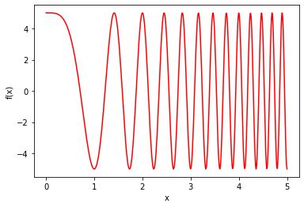

```python
# Import the scientific constants and functions we will use
from numpy import pi,cos

# Set the constants in our function
x1 = 0   # start of pot
x2 = 5   # end of plot
aa = 5   # the constant A

# Make an array of 500 x values from x1 to x2
xvals = np.linspace(x1,x2,500)

# Compute all 500 f(x) values from the 500 x values
fvals = aa*cos(pi*xvals**2)

# Make the plot, using only a line (no symbol)
plt.plot(xvals,fvals,'r-')
plt.xlabel('x')
plt.ylabel('f(x)')
plt.show()
```

Notes:

- Python variable names can have capital letters so we could have used `A=5` rather than `aa=5` but it's a good habit for future Python programmers to avoid upper-case letters in variable names (they are conventionally reserved for class names).
- The command `xvals = np.linspace(x1,x2,500)` sets `xs` to **an array of 500 evenly-spaced numbers from `x1` to `x2`**. The function `np.linspace` is very handy for plotting and also for other scientific calculations -- anywhere you want an array of evenly-spaced floating-point numbers.
- The command `fvals = aa*cos(pi*xvals**2)` is an example of an **automatically vectorized calculation**, which is what `numpy` does for us. If `xvals` were a number, then `fvals` would also end up as a number. But since `xvals` is an array of 500 numbers, then `fvals` also ends up as an array of 500 numbers, with the specified function applied to each $x$-value in `xvals`. This is not always so easy for students to understand, and perhaps best introduced by example as above.

Next we plot some more complicated functions: \begin{align} f(x) &= A \ln(3\cos^2(\pi bx) + \sqrt{2}),\\ g(x) &= B e^{-(x-x_0)^2/2\sigma^2}. \end{align}

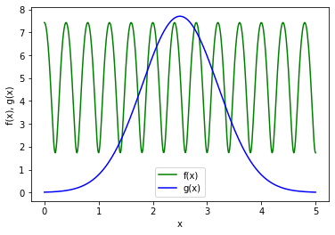

```python
# Import the scientific constants and functions we will use
from numpy import pi,sqrt,log,cos,exp

# Set the constants in our functions
x1 = 0
x2 = 5   # start, end of plot

aa = 5
b = 2.5  # constants in f(x)

bb = 7.7
x0 = 2.5
sigma = 0.7  # constants in g(x)

# Make an array of 500 x values from x1 to x2
xvals = np.linspace(x1,x2,500)

# Compute f(x) values and  g(x) values from the x values
fvals = aa*log(3*cos(pi*b*xvals)**2 + sqrt(2))
gvals = bb*exp(-(xvals-x0)**2/(2*sigma**2))

# Pot the functions:
plt.plot(xvals,fvals,'g-',label='f(x)')
plt.plot(xvals,gvals,'b-',label='g(x)')
plt.legend()
plt.xlabel('x')
plt.ylabel('f(x), g(x)')
plt.show()
```

Possible stumbling points, particularly for students who haven't coded:

- Expression in Python are nearly the same as in other languages like C, C++, Java but note:
  - Powers are expressed using `**` not `^`.
  - The square-root function `sqrt` must be imported along with all other scientifc constants and functions.
- I have found the following to be commom points of confusion for students new to coding when they try to write expressions (these are not specific to Python):
  - Asterisk is needed for all muliplications (can't write `bx` or `b x` for `b*x`).
  - Parentheses are needed for products in denominators (for $x/yz$ need to write `x/(y*z)`, writing `x/y*z` gives the wrong answer).

Different types of plot (points without error bars, points with error bars, curves...) can be combined as you like on the same axes:

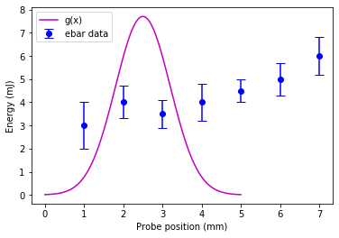

```python
# Re-plot the data with error bars from earlier
plt.errorbar(xs,ys,yerrs,fmt='bo',capsize=5,
            label='ebar data')

# Re-plot the function g(x)
plt.plot(xvals,gvals,'m-',label='g(x)')

# Add  legend and labels and show
plt.legend()
plt.xlabel('Probe position (mm)')
plt.ylabel('Energy (mJ)')
plt.show()
```